# cpbd_analysis

Avishai Wizel

2025-09-28 15:33:00

```r
library(stringi)
library(Seurat)
```

```r
library(ggplot2)
library(tidyverse)
library(dplyr)
library(data.table)
library(print.rmd.tabs)
```

```r
source("./pipe.R")
input = pipeline$cpdb_analysis$input
output = pipeline$cpdb_analysis$output
```

```r
acc_cancer_cd45_caf = readRDS(input$acc_cancer_cd45_caf)
signif_deg =readRDS(input$signif_deg)
```

```r
library(ktplots)


pvals = read.delim(input$pvals,check.names = F)
means = read.delim(input$means,check.names = F)

pvals$interacting_pair = make.unique(pvals$interacting_pair)
means$interacting_pair = make.unique(means$interacting_pair)
```

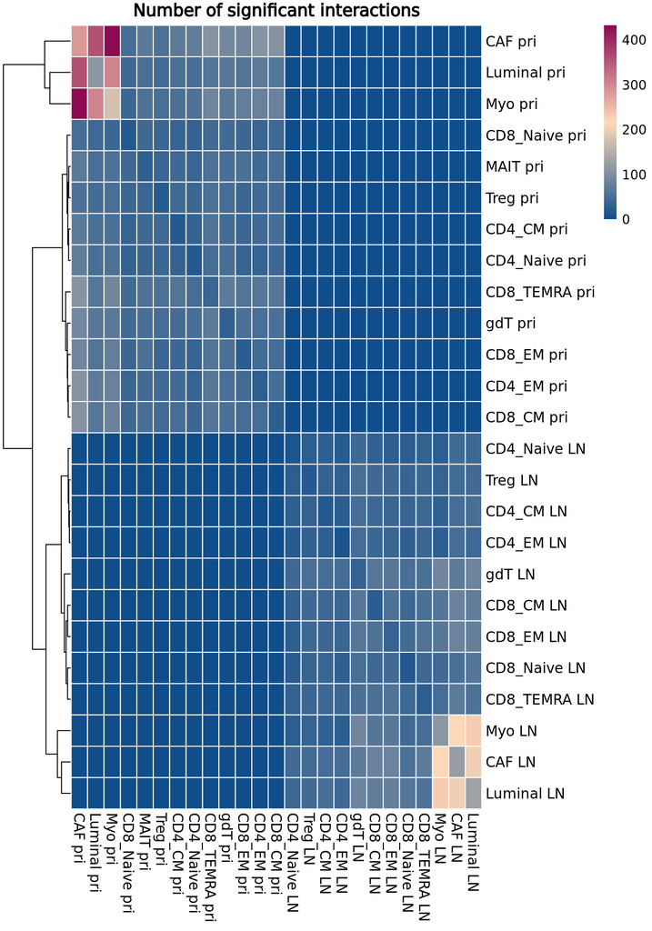

```r
mat = plot_cpdb_heatmap(scdata = acc_cancer_cd45_caf, idents = 'cell_type',pvals =  pvals,main = "Number of significant interactions",alpha = 0.05,treeheight_row = 50,return_tables = T)
```

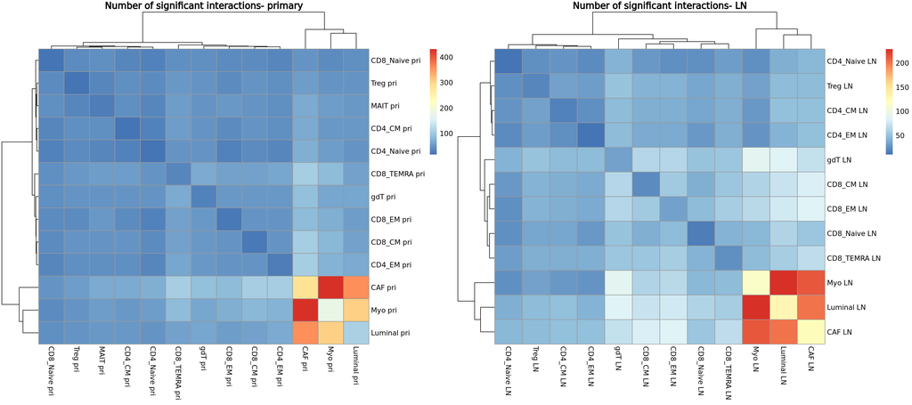

```r
ln_types = acc_cancer_cd45_caf@meta.data %>% filter(tissue == "LN") %>% pull(cell_type) %>% unique()
pri_types = acc_cancer_cd45_caf@meta.data %>% filter(tissue == "pri") %>% pull(cell_type)%>% unique()


p1= pheatmap::pheatmap(mat$count_network[pri_types,pri_types],main = "Number of significant interactions- primary",silent = T) [[4]]
p2 = pheatmap::pheatmap(mat$count_network[ln_types,ln_types],main = "Number of significant interactions- LN",silent = T)[[4]]
gridExtra::grid.arrange(p1, p2,nrow = 1,ncol=2)
```

```r
uniq_interactions <- function(cell_type1, cell_type2_a ,cell_type2_b, gene.family = NULL,genes = NULL) {
  require(purrr)
  a = plot_cpdb(cell_type1 = cell_type1, cell_type2 =cell_type2_a, scdata = acc_cancer_cd45_caf,
                      idents = 'cell_type', means = means, pvals = pvals,
                      gene.family = gene.family,return_table = T, p.adjust.method = "fdr",keep_significant_only = F, genes = genes)

  b = plot_cpdb(cell_type1 = cell_type1, cell_type2 = cell_type2_b, scdata = acc_cancer_cd45_caf,
                      idents = 'cell_type', means = means, pvals = pvals,
                      gene.family = gene.family,return_table = T,p.adjust.method = "fdr",keep_significant_only = F, genes = genes)


  all = list()
  i=0
  nelements = a$Var2 %>% unique() %>% length()
  a_couples = a$Var2 %>% unique()%>% as.vector()
  b_couples = b$Var2 %>% unique()%>% as.vector()
  for (i in 1:nelements) {
    sig_couples_a = a %>% filter(Var2 == a_couples[i]) %>% filter(pvals_adj <= 0.05) %>%  pull(Var1) %>% as.vector()
    sig_couples_b = b %>% filter(Var2 == b_couples[i]) %>% filter(pvals_adj <= 0.05) %>%  pull(Var1) %>% as.vector()
    only_in_a = sig_couples_a[! sig_couples_a %in% sig_couples_b]
    all[[a_couples[i]]] = only_in_a
    i = i+1
  }
  all = t(map_dfr(all, ~as_tibble(t(.)))) %>% as.data.frame() %>%  set_names(a_couples)
  return(all)
}

get_uniq_interactions <- function(cell_type1, cell_type2_a ,cell_type2_b, gene.family = NULL,genes = NULL) {
  require(purrr)
  a = plot_cpdb(cell_type1 = cell_type1, cell_type2 =cell_type2_a, scdata = acc_cancer_cd45_caf,
                      idents = 'cell_type', means = means, pvals = pvals,
                      gene.family = gene.family,return_table = T, p.adjust.method = "fdr",keep_significant_only = F, genes = genes)

  b = plot_cpdb(cell_type1 = cell_type1, cell_type2 = cell_type2_b, scdata = acc_cancer_cd45_caf,
                      idents = 'cell_type', means = means, pvals = pvals,
                      gene.family = gene.family,return_table = T,p.adjust.method = "fdr",keep_significant_only = F, genes = genes)


  all = c()
  i=0
  nelements = a$Var2 %>% unique() %>% length()
  a_couples = a$Var2 %>% unique()%>% as.vector()
  b_couples = b$Var2 %>% unique()%>% as.vector()
  for (i in 1:nelements) {
    sig_couples_a = a %>% filter(Var2 == a_couples[i]) %>% filter(pvals_adj <= 0.05) %>%  pull(Var1) %>% as.vector()
    sig_couples_b = b %>% filter(Var2 == b_couples[i]) %>% filter(pvals_adj <= 0.05) %>%  pull(Var1) %>% as.vector()
    only_in_a = sig_couples_a[! sig_couples_a %in% sig_couples_b]
    uniq_interactions = c(base::setdiff(sig_couples_a, sig_couples_b),  base::setdiff(sig_couples_b, sig_couples_a))
    all = c(all, uniq_interactions)
    i = i+1

  }
  all = gsub(pattern = "-",replacement = "_",x = all)
  return(unique(all))
}

switch_genes <- function(row) {
  first_gene = row[14]
  if (is_null(first_gene)) {first_gene = row[16] %>% gsub(pattern = "complex:",replacement = "")}
  second_gene = row[15]
  if (is_null(second_gene)) {first_gene = row[17] %>% gsub(pattern = "complex:",replacement = "")}

  inverted = paste0(second_gene,"-",first_gene)
}


my_plot_cpdb <- function(...,caf = F) {
  p = plot_cpdb(...)
  pg <- ggplot_build(p)

  ## switch all to ligand-receptor:
  # p_pairs = pg$plot$data$Var1 %>% gsub(pattern = "-",replacement = "_")
  # pval_cut = pvals %>%  column_to_rownames(var = "interacting_pair")
  # pval_cut = pval_cut[p_pairs,c("receptor_a","receptor_b","gene_a","gene_b","partner_a","partner_b")]
  #
  # pg$plot$data = cbind(pg$plot$data, pval_cut)
  # rows_to_switch = pg$plot$data$receptor_a == "False" & pg$plot$data$receptor_b == "True"
  # a = apply(pg$plot$data[169:179,], MARGIN = 1, switch_genes)

  # add facet
  if (caf == F){
    pg$plot$data  %<>%  mutate(lum_or_myo = if_else(condition = grepl(pattern = "Luminal",x = Var2),
                                                    true = "Luminal",false = "Myo"))%>%
      mutate(direction =if_else(condition = grepl(pattern = "-Luminal|-Myo",x = Var2),
                                    true = "cancer->immune" ,false = "immune->cancer"))
      pg$plot+facet_grid(cols = vars(direction,lum_or_myo),scales = "free_x")+ylab("Interacting pair") +
      theme(axis.title.y = element_text(angle = 90,size = 20))

  }else{
    pg$plot$data  %<>%  mutate(direction =if_else(condition = grepl(pattern = "-CAF",x = Var2),true = "CAF->immune",false = "immune->CAF"))
      pg$plot+facet_grid(cols = vars(direction),scales = "free_x")+ylab("Interacting pair") +
      theme(axis.title.y = element_text(angle = 90,size = 20))
  }
}
```

# 1 Costimulatory interactions

```r
print_tab(plt =
            my_plot_cpdb(cell_type1 = 'CD|Treg|gdT', cell_type2 = 'Luminal pri|Myo pri', scdata = acc_cancer_cd45_caf,
                      idents = 'cell_type', means = means, pvals = pvals,
                      gene.family = 'costimulatory',return_table = F,max_size = 3,p.adjust.method = "fdr",
                      keep_significant_only = T,cluster_rows = T)+
            ggtitle("Costimulatory primary")
          ,title = "Primary")
```

## Primary

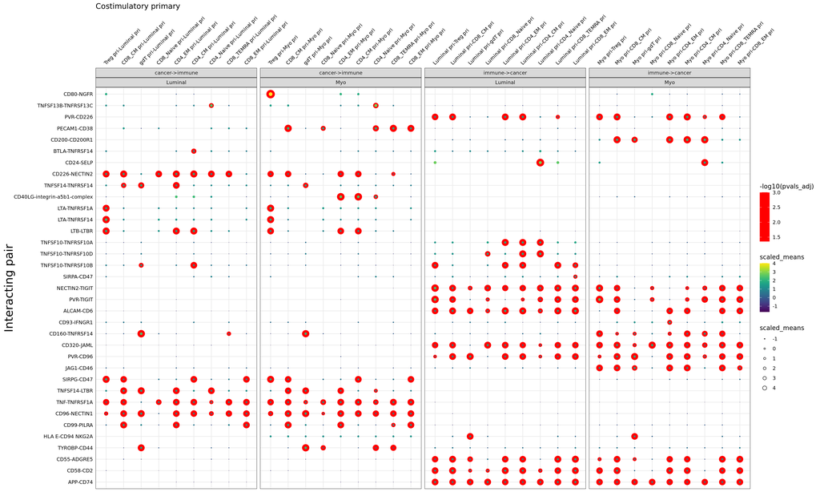

```r
print_tab(plt =
            my_plot_cpdb(cell_type1 = 'CD|Treg|gdT', cell_type2 = 'Luminal LN|Myo LN', scdata = acc_cancer_cd45_caf,
                      idents = 'cell_type', means = means, pvals = pvals,
                      gene.family = 'costimulatory',return_table = F,max_size = 3,p.adjust.method = "fdr",keep_significant_only = T,cluster_rows = F)+
            ggtitle("Costimulatory LN")
  ,title = "LN")
```

## LN

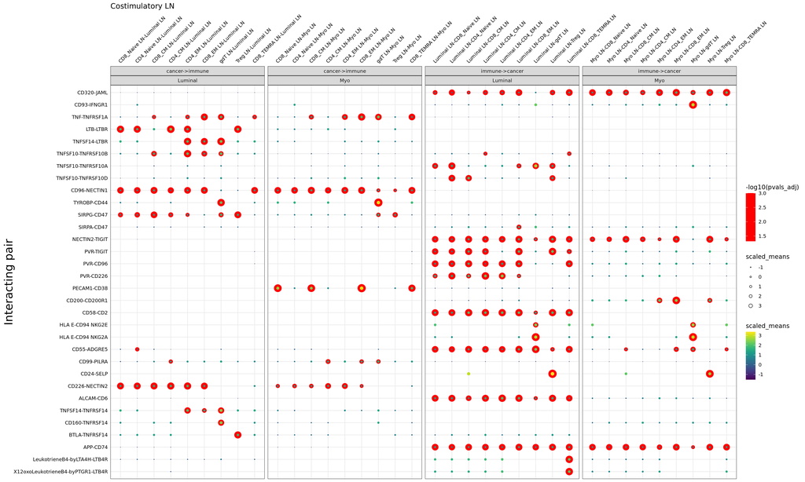

```r
print_tab(plt =
            my_plot_cpdb(cell_type1 = 'CD|Treg|gdT', cell_type2 = 'CAF', scdata = acc_cancer_cd45_caf,
                      idents = 'cell_type', means = means, pvals = pvals,
                      gene.family = 'costimulatory',return_table = F,max_size = 3,p.adjust.method = "fdr",keep_significant_only = T,cluster_rows = F,caf = T)+
            ggtitle("Costimulatory CAF")
  ,title = "CAF")
```

## CAF

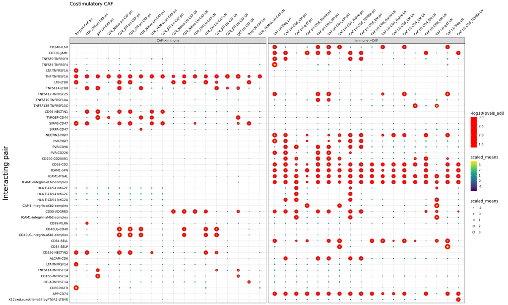

```r
print_tab(plt =
            uniq_interactions(cell_type1 = 'CD|Treg|gdT',cell_type2_a  = 'Luminal pri',cell_type2_b = "Myo",gene.family = "Costimulatory")
,title = "unique in luminal pri")
```

## unique in luminal pri

Luminal pri-Treg pri Luminal pri-CD8_CM pri Luminal pri-gdT pri V1 TNFSF10-TNFRSF10B CD58-CD2 V2 ALCAM-CD6 NECTIN2-TIGIT V3 ALCAM-CD6 V4 Luminal pri-CD8_Naive pri Luminal pri-CD4_EM pri Luminal pri-CD4_CM pri V1 CD58-CD2 TNFSF10-TNFRSF10B TNFSF10-TNFRSF10B V2 ALCAM-CD6 NECTIN2-TIGIT TNFSF10-TNFRSF10D V3 TNFSF10-TNFRSF10D TNFSF10-TNFRSF10A TNFSF10-TNFRSF10A V4 Luminal pri-CD4_Naive pri Luminal pri-CD8_TEMRA pri Luminal pri-CD8_EM pri V1 CD58-CD2 TNFSF10-TNFRSF10B TNFSF10-TNFRSF10B V2 ALCAM-CD6 SIRPA-CD47 V3 TNFSF10-TNFRSF10D V4 TNFSF10-TNFRSF10A Treg pri-Luminal pri CD8_CM pri-Luminal pri gdT pri-Luminal pri V1 TNFSF14-TNFRSF14 TNFSF10-TNFRSF10B V2 V3 V4 CD8_Naive pri-Luminal pri CD4_EM pri-Luminal pri CD4_CM pri-Luminal pri V1 CD226-NECTIN2 TNFSF14-TNFRSF14 TNFSF10-TNFRSF10B V2 BTLA-TNFRSF14 V3 V4 CD4_Naive pri-Luminal pri CD8_TEMRA pri-Luminal pri CD8_EM pri-Luminal pri V1 CD226-NECTIN2 CD160-TNFRSF14 V2 V3 V4

```r
print_tab(plt =
            uniq_interactions(cell_type1 = 'CD|Treg|gdT',cell_type2_a  = 'Myo pri',cell_type2_b = "Luminal",gene.family = "Costimulatory")
,title = "unique in myo pri")
```

## unique in myo pri

Myo pri-Treg pri Myo pri-CD8_CM pri Myo pri-gdT pri Myo pri-CD8_Naive pri V1 JAG1-CD46 JAG1-CD46 JAG1-CD46 V2 CD160-TNFRSF14 CD200-CD200R1 CD320-JAML V3 CD160-TNFRSF14 CD200-CD200R1 V4 CD160-TNFRSF14 Myo pri-CD4_EM pri Myo pri-CD4_CM pri Myo pri-CD4_Naive pri V1 JAG1-CD46 JAG1-CD46 PVR-CD226 V2 CD200-CD200R1 CD200-CD200R1 CD200-CD200R1 V3 CD160-TNFRSF14 CD160-TNFRSF14 CD160-TNFRSF14 V4 CD93-IFNGR1 Myo pri-CD8_TEMRA pri Myo pri-CD8_EM pri Treg pri-Myo pri CD8_CM pri-Myo pri V1 JAG1-CD46 JAG1-CD46 CD80-NGFR PECAM1-CD38 V2 CD160-TNFRSF14 V3 V4 gdT pri-Myo pri CD8_Naive pri-Myo pri CD4_EM pri-Myo pri V1 TNF-TNFRSF1A TYROBP-CD44 CD40LG-integrin-a5b1-complex V2 PECAM1-CD38 V3 CD96-NECTIN1 V4 CD4_CM pri-Myo pri CD4_Naive pri-Myo pri V1 CD40LG-integrin-a5b1-complex TYROBP-CD44 V2 PECAM1-CD38 V3 CD40LG-integrin-a5b1-complex V4 CD8_TEMRA pri-Myo pri CD8_EM pri-Myo pri V1 TYROBP-CD44 PECAM1-CD38 V2 PECAM1-CD38 V3 CD99-PILRA V4

```r
print_tab(plt =
            uniq_interactions(cell_type1 = 'CD|Treg|gdT',cell_type2_a  = 'Luminal LN',cell_type2_b = "Myo",gene.family = "Costimulatory")
,title = "unique in luminal LN")
```

## unique in luminal LN

Luminal LN-CD8_Naive LN Luminal LN-CD4_Naive LN Luminal LN-CD8_CM LN V1 ALCAM-CD6 TNFSF10-TNFRSF10A CD58-CD2 V2 TNFSF10-TNFRSF10A TNFSF10-TNFRSF10D ALCAM-CD6 V3 NECTIN2-TIGIT V4 PVR-TIGIT V5 TNFSF10-TNFRSF10D V6 PVR-CD226 Luminal LN-CD4_CM LN Luminal LN-CD4_EM LN Luminal LN-CD8_EM LN V1 CD55-ADGRE5 NECTIN2-TIGIT SIRPA-CD47 V2 CD58-CD2 TNFSF10-TNFRSF10A V3 PVR-CD96 V4 ALCAM-CD6 V5 TNFSF10-TNFRSF10B V6 PVR-CD226 Luminal LN-gdT LN Luminal LN-Treg LN Luminal LN-CD8_TEMRA LN V1 CD55-ADGRE5 TNFSF10-TNFRSF10A TNFSF10-TNFRSF10B V2 CD58-CD2 CD24-SELP LeukotrieneB4-byLTA4H-LTB4R V3 ALCAM-CD6 TNFSF10-TNFRSF10D X12oxoLeukotrieneB4-byPTGR1-LTB4R V4 HLA E-CD94 NKG2A V5 HLA E-CD94 NKG2E V6 TNFSF10-TNFRSF10A CD8_Naive LN-Luminal LN CD4_Naive LN-Luminal LN CD8_CM LN-Luminal LN V1 CD55-ADGRE5 SIRPG-CD47 V2 LTB-LTBR TNFSF10-TNFRSF10B V3 CD226-NECTIN2 V4 V5 V6 CD4_CM LN-Luminal LN CD4_EM LN-Luminal LN CD8_EM LN-Luminal LN V1 CD99-PILRA SIRPG-CD47 TNFSF10-TNFRSF10B V2 SIRPG-CD47 TNFSF10-TNFRSF10B TNFSF14-TNFRSF14 V3 LTB-LTBR TNFSF14-TNFRSF14 TNFSF14-LTBR V4 CD226-NECTIN2 V5 V6 gdT LN-Luminal LN Treg LN-Luminal LN CD8_TEMRA LN-Luminal LN V1 SIRPG-CD47 SIRPG-CD47 V2 TNFSF10-TNFRSF10B LTB-LTBR V3 TNFSF14-TNFRSF14 BTLA-TNFRSF14 V4 CD160-TNFRSF14 V5 V6

```r
print_tab(plt =
            uniq_interactions(cell_type1 = 'CD|Treg|gdT',cell_type2_a  = 'Myo LN',cell_type2_b = "Luminal",gene.family = "Costimulatory")
,title = "unique in myo LN")
```

## unique in myo LN

Myo LN-CD8_Naive LN Myo LN-CD4_Naive LN Myo LN-CD8_CM LN Myo LN-CD4_CM LN V1 CD320-JAML V2 V3 V4 Myo LN-CD4_EM LN Myo LN-CD8_EM LN Myo LN-gdT LN Myo LN-Treg LN V1 CD200-CD200R1 CD200-CD200R1 CD55-ADGRE5 CD24-SELP V2 HLA E-CD94 NKG2A CD200-CD200R1 V3 HLA E-CD94 NKG2E V4 CD93-IFNGR1 Myo LN-CD8_TEMRA LN CD8_Naive LN-Myo LN CD4_Naive LN-Myo LN CD8_CM LN-Myo LN V1 PECAM1-CD38 TNF-TNFRSF1A V2 CD226-NECTIN2 V3 PECAM1-CD38 V4 CD4_CM LN-Myo LN CD4_EM LN-Myo LN CD8_EM LN-Myo LN gdT LN-Myo LN V1 CD99-PILRA CD99-PILRA TYROBP-CD44 V2 CD96-NECTIN1 PECAM1-CD38 SIRPG-CD47 V3 CD99-PILRA V4 Treg LN-Myo LN CD8_TEMRA LN-Myo LN V1 SIRPG-CD47 PECAM1-CD38 V2 V3 V4

# 2 Coinhibitory interactions

```r
print_tab(my_plot_cpdb(cell_type1 = 'CD|Treg|gdT', cell_type2 = 'Luminal pri|Myo pri', scdata = acc_cancer_cd45_caf,
          idents = 'cell_type', means = means, pvals = pvals,
          gene.family = 'coinhibitory',return_table = F,max_size = 4,p.adjust.method = "fdr",keep_significant_only = F,cluster_rows = F)+
  ggtitle("coinhibitory primary"),title = "Primary")
```

## Primary

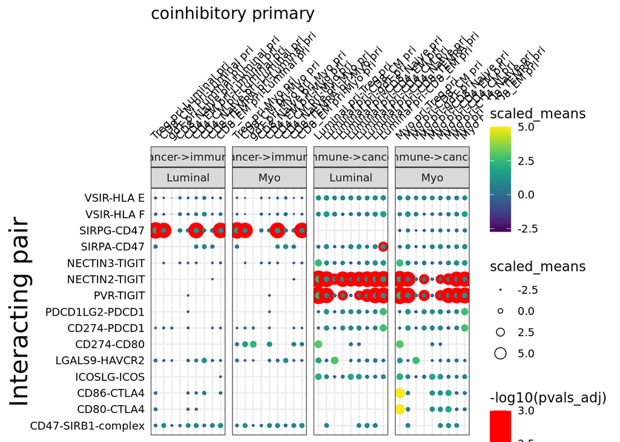

```r
print_tab(my_plot_cpdb(cell_type1 = 'CD|Treg|gdT', cell_type2 = 'Luminal LN|Myo LN', scdata = acc_cancer_cd45_caf,
          idents = 'cell_type', means = means, pvals = pvals,
          gene.family = 'coinhibitory',return_table = F,max_size = 4,p.adjust.method = "fdr",keep_significant_only = F,cluster_rows = F)+
  ggtitle("coinhibitory LN"),title = "LN")
```

## LN

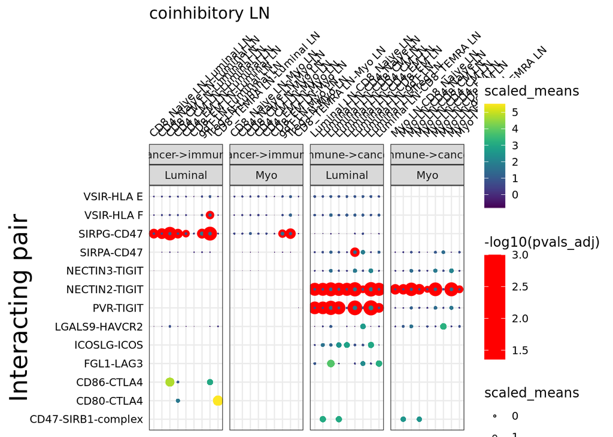

```r
print_tab(plt =
            my_plot_cpdb(cell_type1 = 'CD|Treg|gdT', cell_type2 = 'CAF', scdata = acc_cancer_cd45_caf,
                      idents = 'cell_type', means = means, pvals = pvals,
                      gene.family = 'coinhibitory',return_table = F,max_size = 3,p.adjust.method = "fdr",keep_significant_only = T,cluster_rows = F,caf = T)+
            ggtitle("coinhibitory CAF")
  ,title = "CAF")
```

## CAF

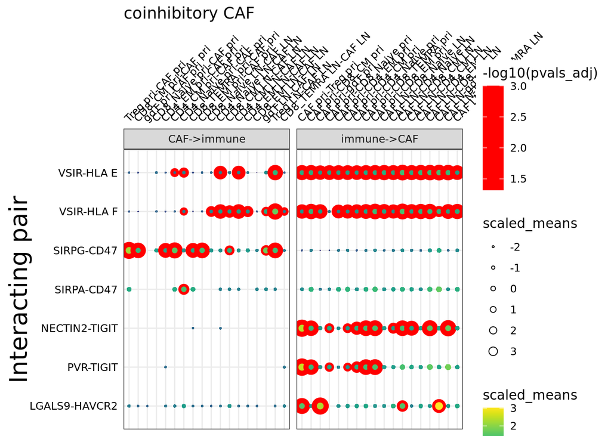

```r
print_tab(plt =
            uniq_interactions(cell_type1 = 'CD|Treg|gdT',cell_type2_a  = 'Luminal LN',cell_type2_b = "Myo LN",gene.family = "coinhibitory")
,title = "unique in luminal LN")
```

## unique in luminal LN

Luminal LN-CD8_Naive LN Luminal LN-CD4_Naive LN Luminal LN-CD8_CM LN V1 PVR-TIGIT PVR-TIGIT PVR-TIGIT V2 Luminal LN-CD4_CM LN Luminal LN-CD4_EM LN Luminal LN-CD8_EM LN V1 PVR-TIGIT SIRPA-CD47 V2 PVR-TIGIT Luminal LN-gdT LN Luminal LN-Treg LN Luminal LN-CD8_TEMRA LN V1 NECTIN2-TIGIT PVR-TIGIT PVR-TIGIT V2 CD8_Naive LN-Luminal LN CD4_Naive LN-Luminal LN CD8_CM LN-Luminal LN V1 SIRPG-CD47 SIRPG-CD47 SIRPG-CD47 V2 CD4_CM LN-Luminal LN CD4_EM LN-Luminal LN CD8_EM LN-Luminal LN V1 SIRPG-CD47 SIRPG-CD47 V2 gdT LN-Luminal LN Treg LN-Luminal LN CD8_TEMRA LN-Luminal LN V1 VSIR-HLA F V2

```r
print_tab(plt =
            uniq_interactions(cell_type1 = 'CD|Treg|gdT',cell_type2_a  = 'Myo LN',cell_type2_b = "Luminal LN",gene.family = "coinhibitory")
,title = "unique in myo LN")
```

## unique in myo LN

[1] Myo LN-CD8_Naive LN Myo LN-CD4_Naive LN Myo LN-CD8_CM LN  
[4] Myo LN-CD4_CM LN Myo LN-CD4_EM LN Myo LN-CD8_EM LN  
[7] Myo LN-gdT LN Myo LN-Treg LN Myo LN-CD8_TEMRA LN [10] CD8_Naive LN-Myo LN CD4_Naive LN-Myo LN CD8_CM LN-Myo LN  
[13] CD4_CM LN-Myo LN CD4_EM LN-Myo LN CD8_EM LN-Myo LN  
[16] gdT LN-Myo LN Treg LN-Myo LN CD8_TEMRA LN-Myo LN <0 rows> (or 0-length row.names)

```r
print_tab(plt =
            uniq_interactions(cell_type1 = 'CD|Treg|gdT',cell_type2_a  = 'Luminal pri',cell_type2_b = "Myo pri",gene.family = "coinhibitory")
,title = "unique in luminal pri")
```

## unique in luminal pri

Luminal pri-Treg pri Luminal pri-CD8_CM pri Luminal pri-gdT pri V1 NECTIN2-TIGIT Luminal pri-CD8_Naive pri Luminal pri-CD4_EM pri Luminal pri-CD4_CM pri V1 NECTIN2-TIGIT Luminal pri-CD4_Naive pri Luminal pri-CD8_TEMRA pri Luminal pri-CD8_EM pri V1 SIRPA-CD47 Treg pri-Luminal pri CD8_CM pri-Luminal pri gdT pri-Luminal pri V1 CD8_Naive pri-Luminal pri CD4_EM pri-Luminal pri CD4_CM pri-Luminal pri V1 CD4_Naive pri-Luminal pri CD8_TEMRA pri-Luminal pri CD8_EM pri-Luminal pri V1

```r
print_tab(plt =
            uniq_interactions(cell_type1 = 'CD|Treg|gdT',cell_type2_a  = 'Myo pri',cell_type2_b = "Luminal pri",gene.family = "coinhibitory")
,title = "unique in myo pri")
```

## unique in myo pri

[1] Myo pri-Treg pri Myo pri-CD8_CM pri Myo pri-gdT pri  
[4] Myo pri-CD8_Naive pri Myo pri-CD4_EM pri Myo pri-CD4_CM pri  
[7] Myo pri-CD4_Naive pri Myo pri-CD8_TEMRA pri Myo pri-CD8_EM pri  
[10] Treg pri-Myo pri CD8_CM pri-Myo pri gdT pri-Myo pri  
[13] CD8_Naive pri-Myo pri CD4_EM pri-Myo pri CD4_CM pri-Myo pri  
[16] CD4_Naive pri-Myo pri CD8_TEMRA pri-Myo pri CD8_EM pri-Myo pri  
<0 rows> (or 0-length row.names)

# 3 Chemokines interactions

```r
print_tab(
  my_plot_cpdb(cell_type1 = 'CD|Treg|gdT', cell_type2 = 'Luminal pri|Myo pri', scdata = acc_cancer_cd45_caf,
          idents = 'cell_type', means = means, pvals = pvals,
          gene.family = 'chemokines',return_table = F,max_size = 4,p.adjust.method = "fdr",keep_significant_only = F,cluster_rows = F)+
  ggtitle("chemokines primary"),title = "Primary")
```

## Primary

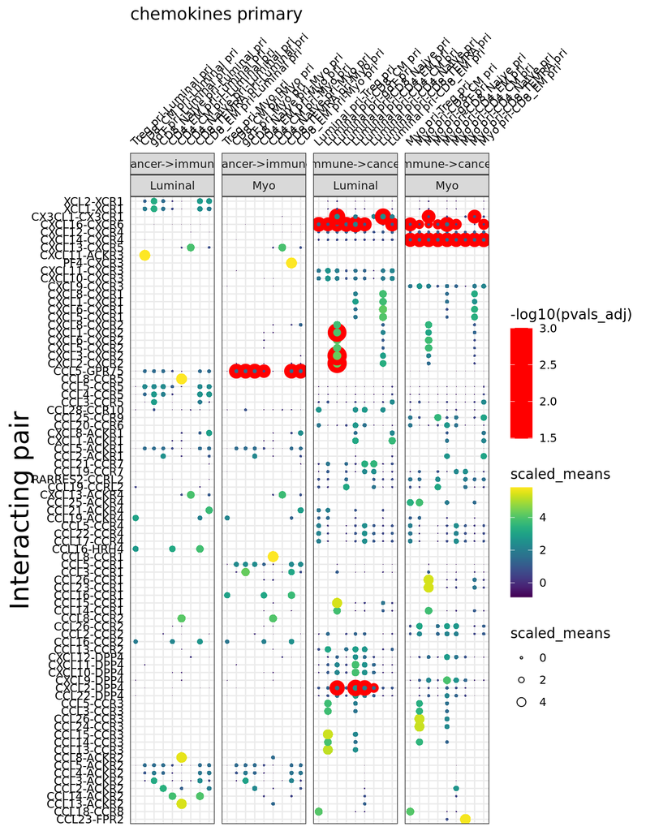

```r
print_tab(
  my_plot_cpdb(cell_type1 = 'CD|Treg|gdT', cell_type2 = 'Luminal LN|Myo LN', scdata = acc_cancer_cd45_caf,
          idents = 'cell_type', means = means, pvals = pvals,
          gene.family = 'chemokines',return_table = F,max_size = 4,p.adjust.method = "fdr",keep_significant_only = F,cluster_rows = F)+
  ggtitle("chemokines LN"),title = "LN")
```

## LN

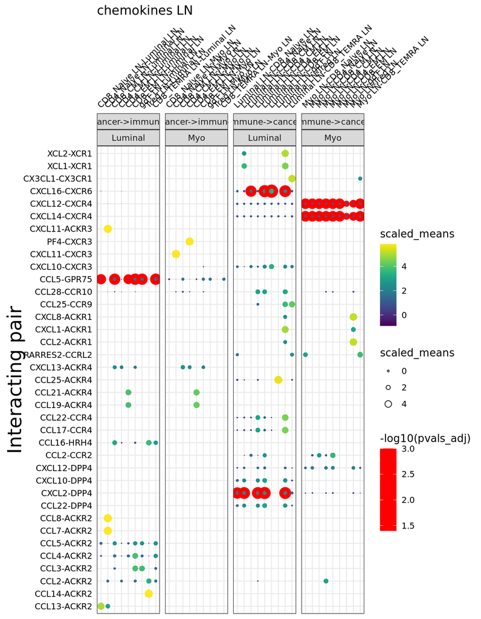

```r
print_tab(plt =
            my_plot_cpdb(cell_type1 = 'CD|Treg|gdT', cell_type2 = 'CAF', scdata = acc_cancer_cd45_caf,
                      idents = 'cell_type', means = means, pvals = pvals,
                      gene.family = 'chemokines',return_table = F,max_size = 3,p.adjust.method = "fdr",keep_significant_only = T,cluster_rows = F,caf = T)+
            ggtitle("chemokines CAF")
  ,title = "CAF")
```

## CAF

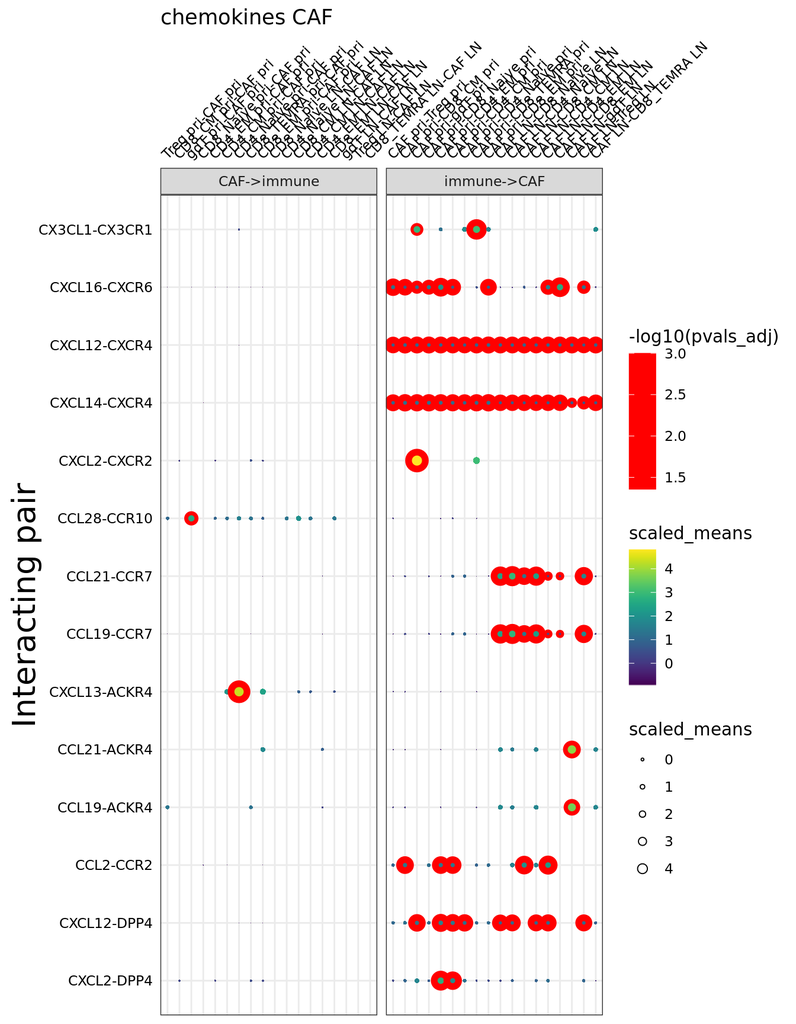

```r
print_tab(plt =
            uniq_interactions(cell_type1 = 'CD|Treg|gdT',cell_type2_a  = 'Luminal LN',cell_type2_b = "Myo LN",gene.family = "chemokines")
,title = "unique in luminal LN")
```

## unique in luminal LN

Luminal LN-CD8_Naive LN Luminal LN-CD4_Naive LN Luminal LN-CD8_CM LN V1 CXCL2-DPP4 CXCL2-DPP4 CXCL16-CXCR6 V2 Luminal LN-CD4_CM LN Luminal LN-CD4_EM LN Luminal LN-CD8_EM LN V1 CXCL2-DPP4 CXCL16-CXCR6 CXCL16-CXCR6 V2 CXCL2-DPP4 Luminal LN-gdT LN Luminal LN-Treg LN Luminal LN-CD8_TEMRA LN V1 CXCL16-CXCR6 V2 CXCL2-DPP4 CD8_Naive LN-Luminal LN CD4_Naive LN-Luminal LN CD8_CM LN-Luminal LN V1 CCL5-GPR75 CCL5-GPR75 V2 CD4_CM LN-Luminal LN CD4_EM LN-Luminal LN CD8_EM LN-Luminal LN V1 CCL5-GPR75 CCL5-GPR75 V2 gdT LN-Luminal LN Treg LN-Luminal LN CD8_TEMRA LN-Luminal LN V1 CCL5-GPR75 CCL5-GPR75 V2

```r
print_tab(plt =
            uniq_interactions(cell_type1 = 'CD|Treg|gdT',cell_type2_a  = 'Myo LN',cell_type2_b = "Luminal LN",gene.family = "chemokines")
,title = "unique in myo LN")
```

## unique in myo LN

Myo LN-CD8_Naive LN Myo LN-CD4_Naive LN Myo LN-CD8_CM LN Myo LN-CD4_CM LN V1 CXCL14-CXCR4 CXCL14-CXCR4 CXCL14-CXCR4 CXCL14-CXCR4 V2 CXCL12-CXCR4 CXCL12-CXCR4 CXCL12-CXCR4 CXCL12-CXCR4 Myo LN-CD4_EM LN Myo LN-CD8_EM LN Myo LN-gdT LN Myo LN-Treg LN V1 CXCL14-CXCR4 CXCL14-CXCR4 CXCL14-CXCR4 CXCL14-CXCR4 V2 CXCL12-CXCR4 CXCL12-CXCR4 CXCL12-CXCR4 CXCL12-CXCR4 Myo LN-CD8_TEMRA LN CD8_Naive LN-Myo LN CD4_Naive LN-Myo LN CD8_CM LN-Myo LN V1 CXCL14-CXCR4 V2 CXCL12-CXCR4 CD4_CM LN-Myo LN CD4_EM LN-Myo LN CD8_EM LN-Myo LN gdT LN-Myo LN V1 V2 Treg LN-Myo LN CD8_TEMRA LN-Myo LN V1 V2

```r
print_tab(plt =
            uniq_interactions(cell_type1 = 'CD|Treg|gdT',cell_type2_a  = 'Luminal pri',cell_type2_b = "Myo pri",gene.family = "chemokines")
,title = "unique in luminal pri")
```

## unique in luminal pri

Luminal pri-Treg pri Luminal pri-CD8_CM pri Luminal pri-gdT pri V1 CXCL2-CXCR2 V2 CXCL3-CXCR2 V3 CXCL1-CXCR2 V4 CXCL2-DPP4 Luminal pri-CD8_Naive pri Luminal pri-CD4_EM pri Luminal pri-CD4_CM pri V1 CXCL2-DPP4 CXCL2-DPP4 V2 V3 V4 Luminal pri-CD4_Naive pri Luminal pri-CD8_TEMRA pri Luminal pri-CD8_EM pri V1 CXCL2-DPP4 V2 V3 V4 Treg pri-Luminal pri CD8_CM pri-Luminal pri gdT pri-Luminal pri V1 V2 V3 V4 CD8_Naive pri-Luminal pri CD4_EM pri-Luminal pri CD4_CM pri-Luminal pri V1 V2 V3 V4 CD4_Naive pri-Luminal pri CD8_TEMRA pri-Luminal pri CD8_EM pri-Luminal pri V1 V2 V3 V4

```r
print_tab(plt =
            uniq_interactions(cell_type1 = 'CD|Treg|gdT',cell_type2_a  = 'Myo pri',cell_type2_b = "Luminal pri",gene.family = "chemokines")
,title = "unique in myo pri")
```

## unique in myo pri

Myo pri-Treg pri Myo pri-CD8_CM pri Myo pri-gdT pri Myo pri-CD8_Naive pri V1 CXCL14-CXCR4 CXCL14-CXCR4 CXCL14-CXCR4 CXCL14-CXCR4 Myo pri-CD4_EM pri Myo pri-CD4_CM pri Myo pri-CD4_Naive pri V1 CXCL14-CXCR4 CXCL14-CXCR4 CXCL14-CXCR4 Myo pri-CD8_TEMRA pri Myo pri-CD8_EM pri Treg pri-Myo pri CD8_CM pri-Myo pri V1 CXCL14-CXCR4 CXCL14-CXCR4 CCL5-GPR75 gdT pri-Myo pri CD8_Naive pri-Myo pri CD4_EM pri-Myo pri CD4_CM pri-Myo pri V1 CCL5-GPR75 CCL5-GPR75 CCL5-GPR75 CD4_Naive pri-Myo pri CD8_TEMRA pri-Myo pri CD8_EM pri-Myo pri V1 CCL5-GPR75 CCL5-GPR75

# 4 Chemokine ligands

```r
genes = c("CXCL1\\D", "CXCL2\\D","CXCL3\\D","CXCL17","C3","CXCL14")
print_tab(my_plot_cpdb(cell_type1 = 'CD|Treg|gdT', cell_type2 = 'Luminal pri|Myo pri', scdata = acc_cancer_cd45_caf,
    idents = 'cell_type', means = means, pvals = pvals,
 genes = genes,return_table = F,max_size = 4,p.adjust.method = "fdr" ,keep_significant_only = F)
 ,title = "Primary")
```

## Primary

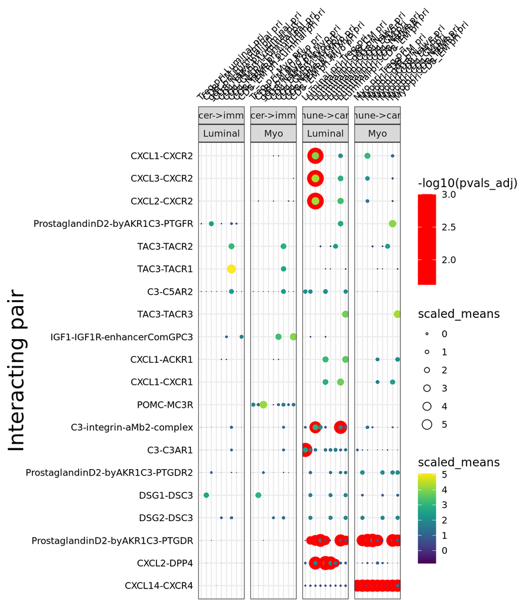

```r
print_tab(my_plot_cpdb(cell_type1 = 'CD|Treg|gdT', cell_type2 = 'Luminal LN|Myo LN', scdata = acc_cancer_cd45_caf,
    idents = 'cell_type', means = means, pvals = pvals,
  genes = genes,return_table = F,max_size = 4,p.adjust.method = "fdr" ,keep_significant_only = F)
,title = "LN")
```

## LN

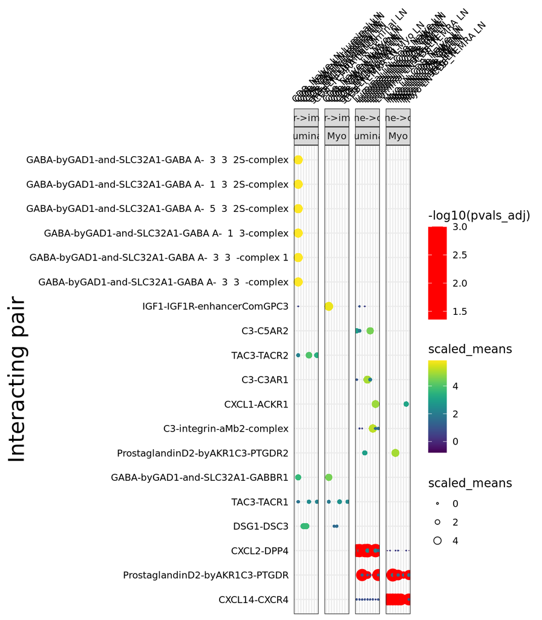

```r
print_tab(plt =
            uniq_interactions(cell_type1 = 'CD|Treg|gdT',cell_type2_a  = 'Luminal LN',cell_type2_b = "Myo LN",genes = genes)
,title = "unique in luminal LN")
```

## unique in luminal LN

Luminal LN-CD8_Naive LN Luminal LN-CD4_Naive LN Luminal LN-CD8_CM LN V1 CXCL2-DPP4 CXCL2-DPP4 Luminal LN-CD4_CM LN Luminal LN-CD4_EM LN Luminal LN-CD8_EM LN V1 CXCL2-DPP4 CXCL2-DPP4 Luminal LN-gdT LN Luminal LN-Treg LN Luminal LN-CD8_TEMRA LN V1 CXCL2-DPP4 CD8_Naive LN-Luminal LN CD4_Naive LN-Luminal LN CD8_CM LN-Luminal LN V1 CD4_CM LN-Luminal LN CD4_EM LN-Luminal LN CD8_EM LN-Luminal LN V1 gdT LN-Luminal LN Treg LN-Luminal LN CD8_TEMRA LN-Luminal LN V1

```r
print_tab(plt =
            uniq_interactions(cell_type1 = 'CD|Treg|gdT',cell_type2_a  = 'Myo LN',cell_type2_b = "Luminal LN",genes = genes)
,title = "unique in myo LN")
```

## unique in myo LN

Myo LN-CD8_Naive LN Myo LN-CD4_Naive LN Myo LN-CD8_CM LN Myo LN-CD4_CM LN V1 CXCL14-CXCR4 CXCL14-CXCR4 CXCL14-CXCR4 CXCL14-CXCR4 V2 Myo LN-CD4_EM LN Myo LN-CD8_EM LN Myo LN-gdT LN V1 CXCL14-CXCR4 CXCL14-CXCR4 CXCL14-CXCR4 V2 ProstaglandinD2-byAKR1C3-PTGDR Myo LN-Treg LN Myo LN-CD8_TEMRA LN CD8_Naive LN-Myo LN CD4_Naive LN-Myo LN V1 CXCL14-CXCR4 CXCL14-CXCR4 V2 CD8_CM LN-Myo LN CD4_CM LN-Myo LN CD4_EM LN-Myo LN CD8_EM LN-Myo LN V1 V2 gdT LN-Myo LN Treg LN-Myo LN CD8_TEMRA LN-Myo LN V1 V2

```r
print_tab(plt =
            uniq_interactions(cell_type1 = 'CD|Treg|gdT',cell_type2_a  = 'Luminal pri',cell_type2_b = "Myo pri",genes = genes)
,title = "unique in luminal pri")
```

## unique in luminal pri

Luminal pri-Treg pri Luminal pri-CD8_CM pri Luminal pri-gdT pri V1 C3-C3AR1 CXCL2-DPP4 V2 CXCL2-CXCR2 V3 CXCL3-CXCR2 V4 CXCL1-CXCR2 V5 C3-integrin-aMb2-complex Luminal pri-CD8_Naive pri Luminal pri-CD4_EM pri Luminal pri-CD4_CM pri V1 CXCL2-DPP4 CXCL2-DPP4 V2 V3 V4 V5 Luminal pri-CD4_Naive pri Luminal pri-CD8_TEMRA pri Luminal pri-CD8_EM pri V1 CXCL2-DPP4 C3-integrin-aMb2-complex V2 V3 V4 V5 Treg pri-Luminal pri CD8_CM pri-Luminal pri gdT pri-Luminal pri V1 V2 V3 V4 V5 CD8_Naive pri-Luminal pri CD4_EM pri-Luminal pri CD4_CM pri-Luminal pri V1 V2 V3 V4 V5 CD4_Naive pri-Luminal pri CD8_TEMRA pri-Luminal pri CD8_EM pri-Luminal pri V1 V2 V3 V4 V5

```r
print_tab(plt =
            uniq_interactions(cell_type1 = 'CD|Treg|gdT',cell_type2_a  = 'Myo pri',cell_type2_b = "Luminal pri",genes = genes)
,title = "unique in myo pri")
```

## unique in myo pri

Myo pri-Treg pri Myo pri-CD8_CM pri Myo pri-gdT pri Myo pri-CD8_Naive pri V1 CXCL14-CXCR4 CXCL14-CXCR4 CXCL14-CXCR4 CXCL14-CXCR4 Myo pri-CD4_EM pri Myo pri-CD4_CM pri Myo pri-CD4_Naive pri V1 CXCL14-CXCR4 CXCL14-CXCR4 CXCL14-CXCR4 Myo pri-CD8_TEMRA pri Myo pri-CD8_EM pri Treg pri-Myo pri CD8_CM pri-Myo pri V1 CXCL14-CXCR4 CXCL14-CXCR4 gdT pri-Myo pri CD8_Naive pri-Myo pri CD4_EM pri-Myo pri CD4_CM pri-Myo pri V1 CD4_Naive pri-Myo pri CD8_TEMRA pri-Myo pri CD8_EM pri-Myo pri V1

# 5 CCL22 and CCL28

```r
print_tab(my_plot_cpdb(cell_type1 = 'CD|Treg|gdT', cell_type2 = 'Luminal pri|Myo pri', scdata = acc_cancer_cd45_caf,
    idents = 'cell_type', means = means, pvals = pvals,
 genes = c("CCL22", "CCL28","CXCL1_","CXCL2_","CXCL3_","CXCL17" ,"CXCL14","IL17RD","^C3_","_C3"),return_table = F,max_size = 4,p.adjust.method = "fdr" ,keep_significant_only = F),title = "Primary")
```

## Primary

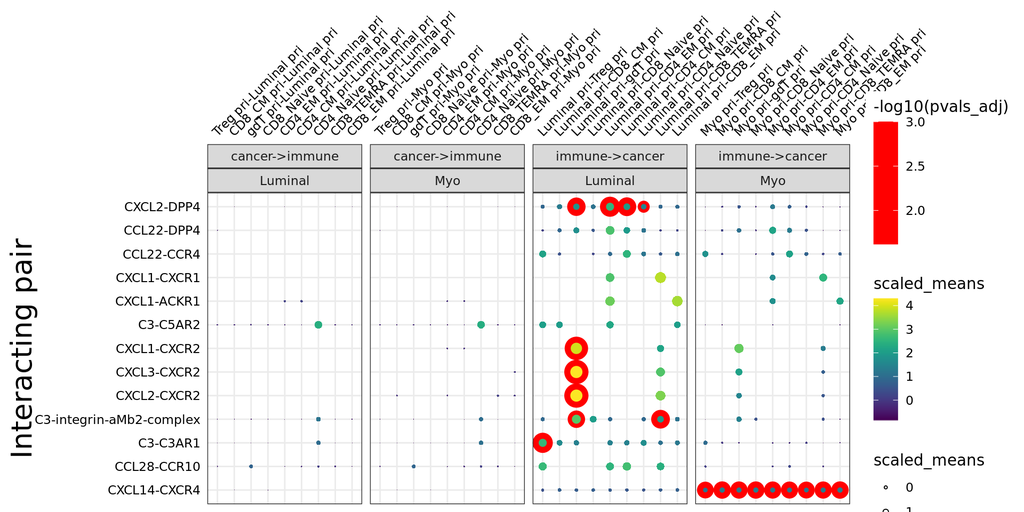

```r
print_tab(my_plot_cpdb(cell_type1 = 'CD|Treg|gdT', cell_type2 = 'Luminal LN|Myo LN', scdata = acc_cancer_cd45_caf,
    idents = 'cell_type', means = means, pvals = pvals,
  genes = c("CCL22", "CCL28" ),return_table = F,max_size = 6,p.adjust.method = "fdr" ,keep_significant_only = F),title = "LN")
```

## LN

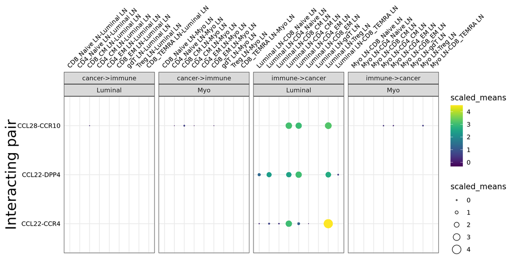

# 6 signif DEG

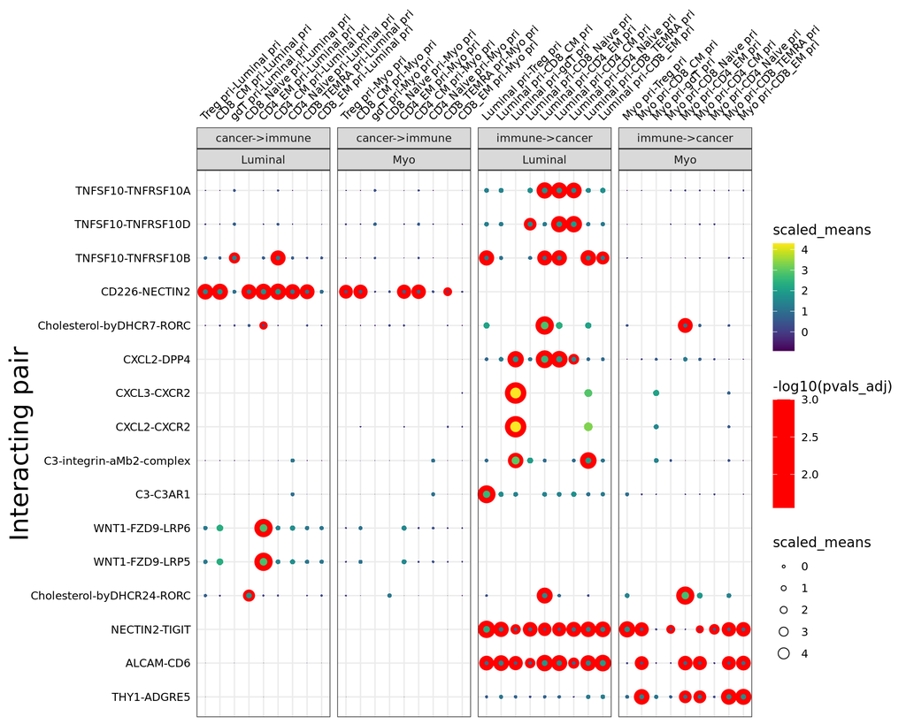

```r
uniq_genes = get_uniq_interactions(cell_type1 = 'CD|Treg|gdT|Den',cell_type2_a  = 'Myo pri',cell_type2_b = "Luminal pri",
                                   genes = rownames( signif_deg %>% filter(avg_log2FC >0)))


my_plot_cpdb(cell_type1 = 'CD|Treg|gdT|Den', cell_type2 = 'Luminal pri|Myo pri', scdata = acc_cancer_cd45_caf,
    idents = 'cell_type', means = means, pvals = pvals,
 genes = uniq_genes,return_table = F,max_size = 4,p.adjust.method = "fdr" ,keep_significant_only = T)
```

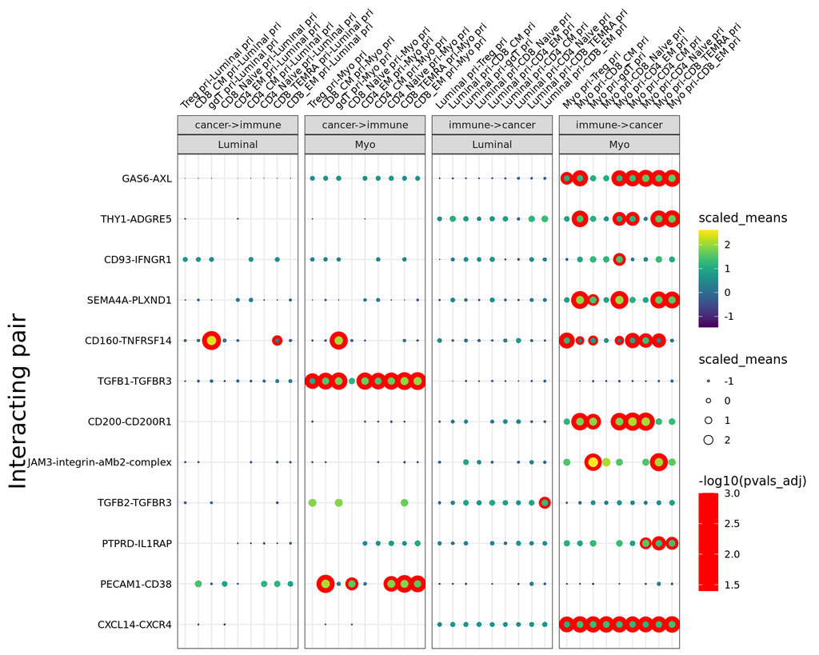

```r
uniq_genes = get_uniq_interactions(cell_type1 = 'CD|Treg|gdT|Den',cell_type2_a  = 'Myo pri',cell_type2_b = "Luminal pri",
                                   genes = rownames( signif_deg %>% filter(avg_log2FC < 0)))


my_plot_cpdb(cell_type1 = 'CD|Treg|gdT|Den', cell_type2 = 'Luminal pri|Myo pri', scdata = acc_cancer_cd45_caf,
    idents = 'cell_type', means = means, pvals = pvals,
 genes = uniq_genes,return_table = F,max_size = 4,p.adjust.method = "fdr" ,keep_significant_only = T)
```

# 7 Notch signaling interactions with immune

```r
print_tab(plt =
            my_plot_cpdb(cell_type1 = 'CD|Treg|gdT', cell_type2 = 'Luminal pri|Myo pri', scdata = acc_cancer_cd45_caf,
                         idents = 'cell_type', means = means, pvals = pvals,
                         genes =c("JAG", "MYB" , "NOTCH","HES1","HEY"),return_table = F,max_size = 4,p.adjust.method = "fdr" ,keep_significant_only = F)
        ,title = "Primary")
```

## Primary

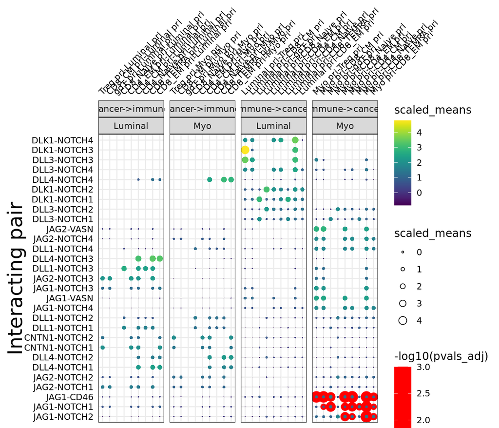

```r
print_tab(plt =
            my_plot_cpdb(cell_type1 = 'CD|Treg|gdT', cell_type2 = 'Luminal LN|Myo LN', scdata = acc_cancer_cd45_caf,
                         idents = 'cell_type', means = means, pvals = pvals,
                         genes =c("JAG", "MYB" , "NOTCH","HES1","HEY"),return_table = F,max_size = 4,p.adjust.method = "fdr" ,keep_significant_only = F)
        ,title = "Primary")
```

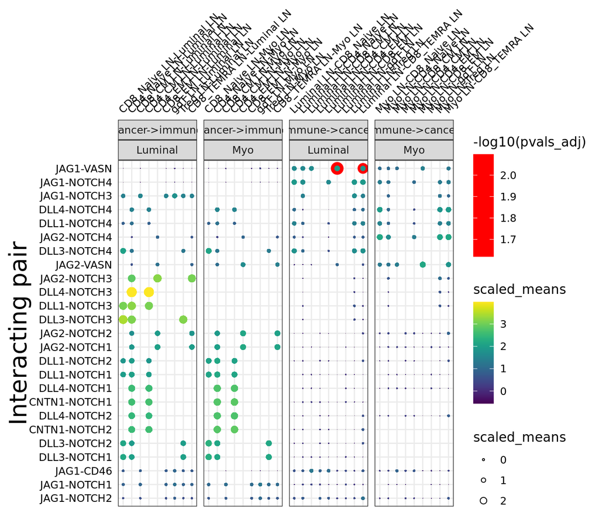

# 8 Notch signaling interactions with CAF

```r
print_tab(plt =
            plot_cpdb(cell_type1 = 'CAF', cell_type2 = 'Luminal pri|Myo pri', scdata = acc_cancer_cd45_caf,
                      idents = 'cell_type', means = means, pvals = pvals,
                      genes = c("JAG", "MYB" ),return_table = F,max_size = 4,p.adjust.method = "fdr" ,keep_significant_only = F)
          ,title = "Primary")
```

## Primary

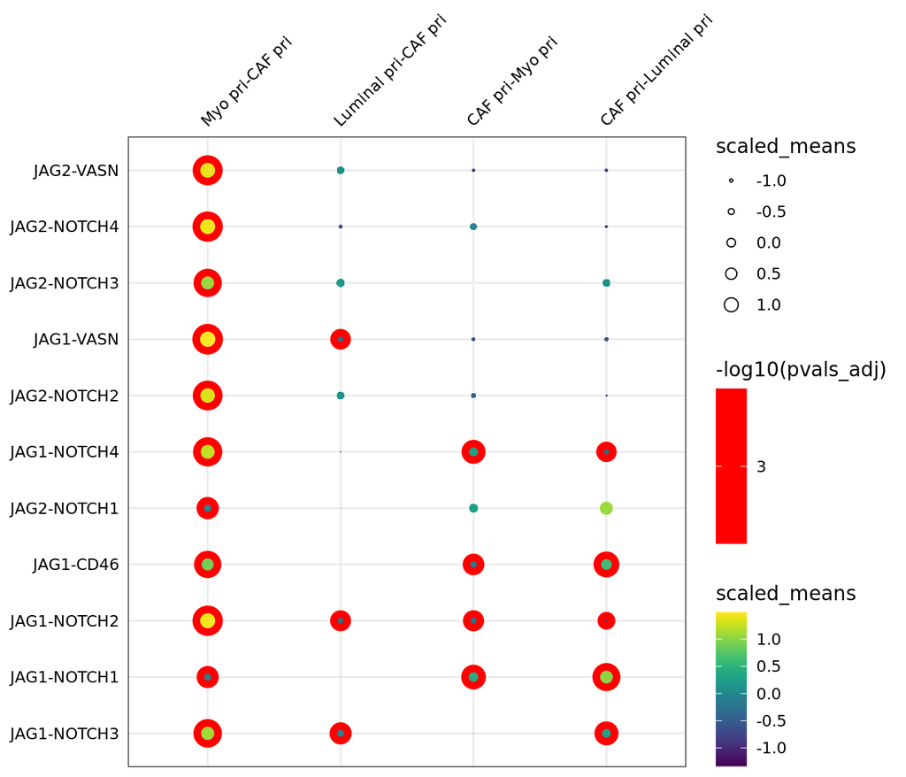

```r
print_tab(plt =
            plot_cpdb(cell_type1 = 'CAF', cell_type2 = 'Luminal LN|Myo LN', scdata = acc_cancer_cd45_caf,
                      idents = 'cell_type', means = means, pvals = pvals,
                      genes = c("JAG", "MYB" ),return_table = F,max_size = 4,p.adjust.method = "fdr" ,keep_significant_only = F)
          ,title = "Primary")
```

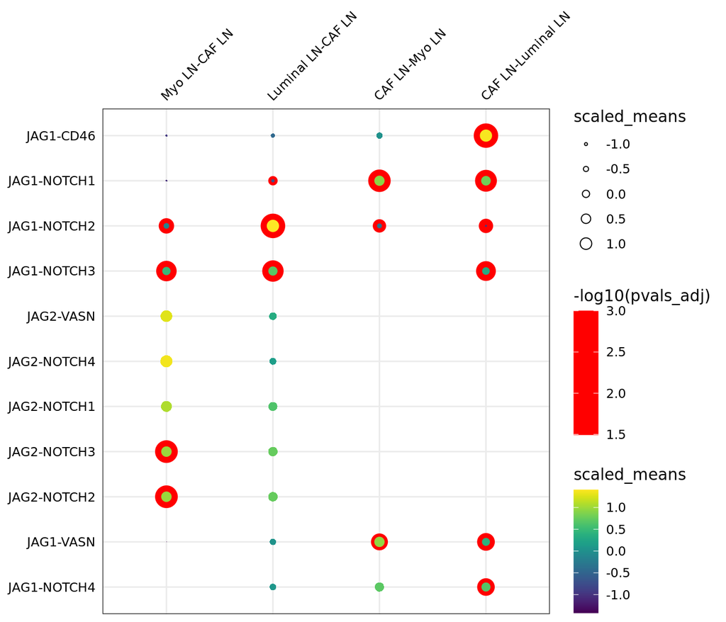